# Informe Trabajo Final

Julian Velandia, Julian Albarracín, Tomas Bermudez

2025-07-27

## 1 Introducción

En el marco del análisis estadístico aplicado a fenómenos sociales, la inferencia estadística se consolida como una herramienta clave para la toma de decisiones basada en datos. Este informe tiene como propósito aplicar los principios fundamentales de la inferencia, junto con técnicas descriptivas y probabilísticas, para estudiar los hábitos diarios en el uso del tiempo libre de una muestra de individuos residentes en Bogotá.

El análisis se fundamenta en una base de datos obtenida a partir de una encuesta telefónica aplicada a 315 personas, en la cual se indagan distintos aspectos del uso cotidiano del tiempo libre: desde el tiempo dedicado a internet y la lectura, hasta la participación en actividades al aire libre o el uso del celular. A partir de esta información, se abordan distintos procedimientos estadísticos con el fin de extraer conclusiones significativas y generalizables.

Durante el presente informe se busca no solo obtener estimaciones puntuales o rangos de confianza, sino también interpretar sus implicaciones prácticas en un contexto real. Este informe incluye estimaciones de parámetros poblacionales a partir de muestras aleatorias, construcción de intervalos de confianza, pruebas de hipótesis, así como análisis de proporciones y diferencias entre subgrupos.

## 2 Marco teórico

### 2.1 Inferencia estadistica

La inferencia estadística es la rama de la estadística que permite **hacer generalizaciones sobre una población a partir de una muestra representativa**. Su objetivo principal es estimar parámetros poblacionales desconocidos ($\mu, \sigma^2, p$) y realizar pruebas de hipótesis que permitan validar o rechazar supuestos sobre dichos parámetros.

Existen dos enfoques principales:

- **Estimación**: incluye la obtención de estimadores puntuales $\hat{\theta}$ y por intervalos $[L, U]$ de un parámetro $\theta$.
- **Contraste de hipótesis**: implica evaluar afirmaciones sobre la población mediante estadísticos de prueba y niveles de significancia $\alpha$.

En términos generales, la inferencia se apoya en el **Teorema Central del Límite**, que establece que, para muestras suficientemente grandes, la distribución de la media muestral $\bar{X}$ se aproxima a una normal:
$$\bar{X} \sim N\left(\mu, \frac{\sigma^2}{n}\right)$$
donde $\mu$ es la media poblacional, $\sigma^2$ la varianza y $n$ el tamaño de la muestra.

### 2.2 Estadisticos

Un estadístico es cualquier función calculada a partir de los datos muestrales que sirve para describir o inferir propiedades de la población. Ejemplos comunes incluyen:

- La **media muestral**:
  $$\bar{X} = \frac{1}{n}\sum_{i=1}^{n} X_i$$
- La **proporción muestral**:
  $$\hat{p} = \frac{x}{n}$$
- La **varianza muestral**:
  $$S^2 = \frac{1}{n-1}\sum_{i=1}^{n}(X_i - \bar{X})^2$$

Los estadísticos son variables aleatorias, ya que dependen de la muestra seleccionada. Su distribución se conoce como **distribución muestral**.

### 2.3 P-value

El p-valor ($p$) es la probabilidad de observar un resultado tan extremo o más extremo que el obtenido en los datos, bajo la suposición de que la hipótesis nula $H_0$ es verdadera. Se interpreta como evidencia en contra de $H_0$:

- Si $p \leq \alpha$: se rechaza $H_0$, hay evidencia estadísticamente significativa.
- Si $p > \alpha$: no se rechaza $H_0$, no hay suficiente evidencia.

Formalmente:
$$p = P(T \geq t_{\text{obs}} \, | \, H_0)$$
donde $T$ es el estadístico de prueba y $t_{\text{obs}}$ el valor observado.

### 2.4 Demostración del intervalo de confianza

Para una media poblacional $\mu$ con varianza conocida $\sigma^2$ y bajo muestreo aleatorio simple, el intervalo de confianza de nivel $(1-\alpha)$ se construye a partir de la normal estándar:
$$P\left(-z_{\alpha/2} \leq \frac{\bar{X}-\mu}{\sigma/\sqrt{n}} \leq
z_{\alpha/2}\right) = 1-\alpha$$

Despejando $\mu$:
$$P\left(\bar{X}-z_{\alpha/2}\frac{\sigma}{\sqrt{n}} \leq \mu \leq
\bar{X}+z_{\alpha/2}\frac{\sigma}{\sqrt{n}}\right) = 1-\alpha$$

Cuando $\sigma$ es desconocida, se reemplaza por $S$ y se utiliza la distribución t de Student con $n-1$ grados de libertad para el intervalo de confianza IC:
$$IC_{(1-\alpha)}: \quad \bar{X} \pm t_{\alpha/2, n-1}\frac{S}{\sqrt{n}}$$

En el caso de una diferencia de medias ($\mu_1 - \mu_2$), el intervalo se generaliza como:
$$IC_{(1-\alpha)}: \quad (\bar{X}_1 - \bar{X}_2) \pm t_{\alpha/2, \, gl}
\cdot \text{EE}(\bar{X}_1 - \bar{X}_2)$$
donde $\text{EE}$ es el error estándar de la diferencia y $gl$ los grados de libertad apropiados (según si se asumen o no varianzas iguales).

## 3 Desarrollo

#### 3.0.1 Enunciado 1.

Realice un ánalisis descriptivo numérico completo para la variable tiempo en internet que incluya las medidas de tendencia central, de variablidad, de posicíon y de forma.

*Análisis Descriptivo Numérico*

```
## Las medidas de tendencia central para la variable tiempo en internet muestran que la media es 2.827619 la mediana es 2.9 y la moda es 3.2
```

```
## La variable tiempo en internet se encuentra entre el rango 0.7 5.2 Tiene una varianza de 0.6509227 y desviación estandar de 0.8067978 Por lo que el coeficiente de variación resulta ser 28.53276
```

```
## Como medidas de posición utilizamos los cuartiles en 25%, 50% y 75%, es decir, 2.3 2.9 3.4 respectivamente.
```

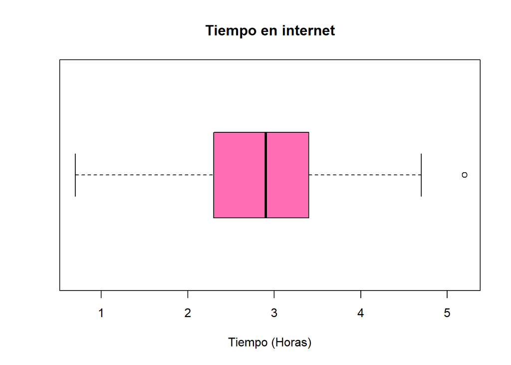

```
## Para las medidas de posición utilizamos la asimetria y la curtosis. Asimetría:  -0.1504161 Curtosis: -0.2610799
```

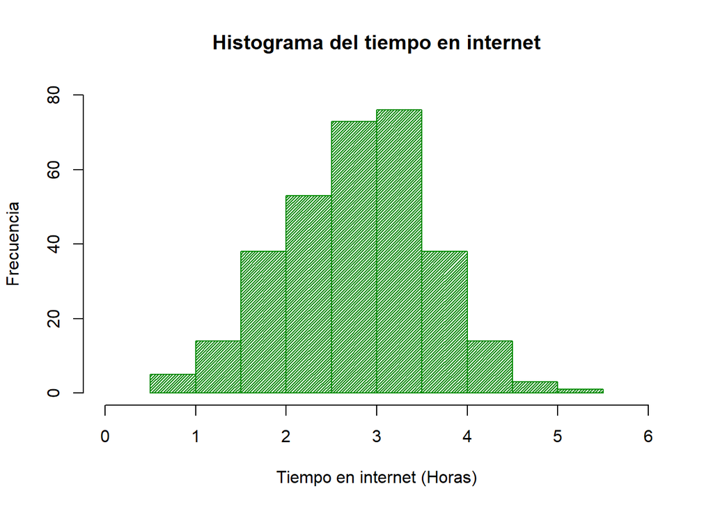

#### 3.0.2 Enunciado 2.

Tome una muestra aleatoria de 69 datos utilizando como semilla los últimos dígitos del documento de identidad de cada integrante del grupo y, con base en esa muestra, realice los siguientes ejercicios.

*Solución*

```
## Muestra creada con tamaño de 69 datos y utilizando la semilla 455
```

#### 3.0.3 Enunciado 3.

Construya un intervalo de confianza del 95 % para la media del tiempo dedicado a la lectura en la muestra. Interprete su resultado.

*Solución*

```
## [1] 0.7543427 1.1297152
## attr(,"conf.level")
## [1] 0.95
```

```
## El intervalo de confianza se encuentra entre: 0.7543427 y 1.1297152
```

#### 3.0.4 Enunciado 4.

¿Hay diferencias significativas en el tiempo promedio dedicado a actividades al aire libre entre hombres y mujeres? Realice una prueba de hipótesis para comparar las medias y construya un intervalo de confianza del 99 % para la diferencia.

*Solución*

```
## El rango del tiempo dedicado al aire libre de los hombres es: 0 2.6
```

```
## El rango del tiempo dedicado al aire libre de las mujeres es: 0.1 3.2
```

Es necesario ahora realizar pruebas de normalidad para las distribuciones del tiempo al aire libre de los hombre y para el tiempo al aire libre de las mujeres. Si se encuentra que las distribuciones son normales, se puede continuar a la evalución de los promedios y la diferencia entre los mismos.

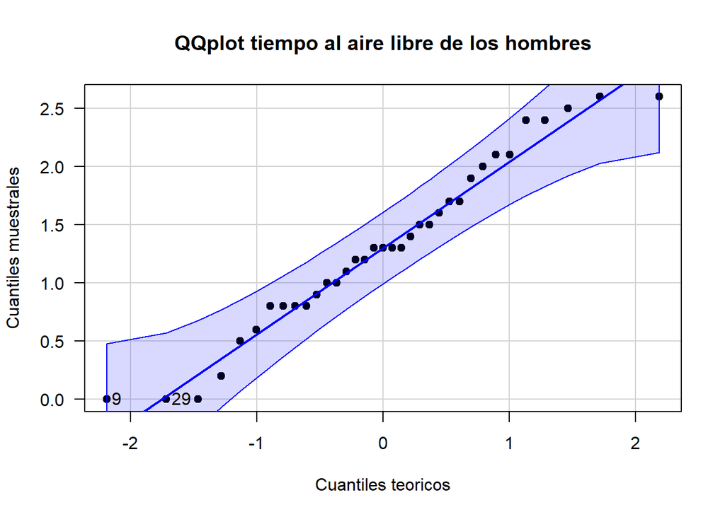

```
## [1]  9 29
```

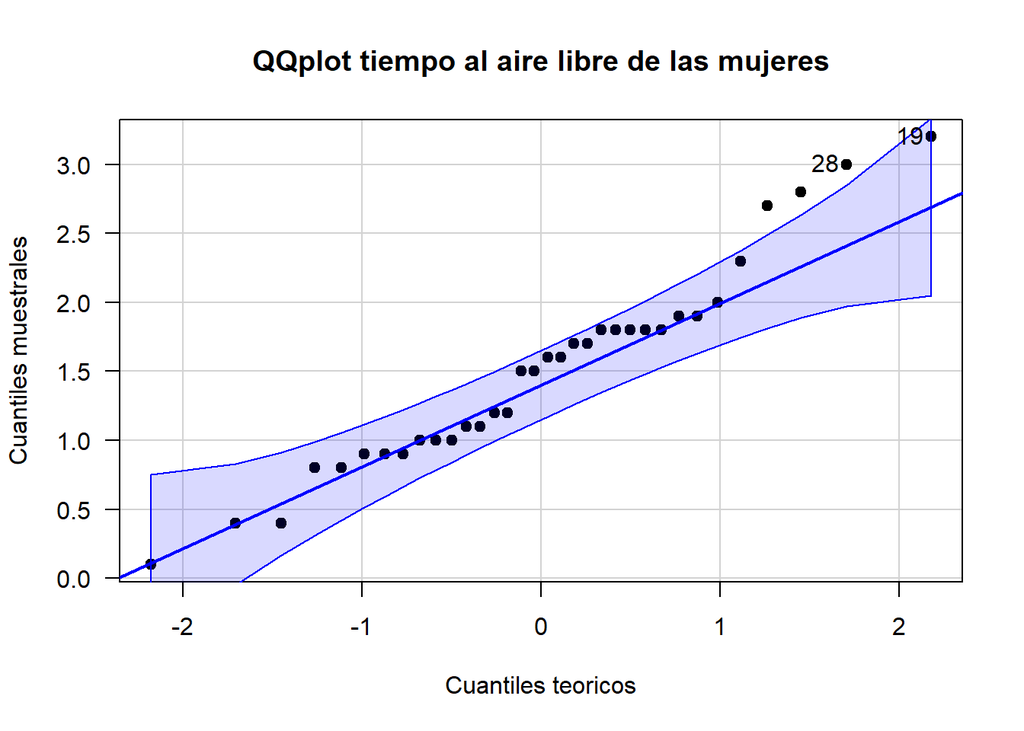

```
## [1] 19 28
```

```
##
##  Shapiro-Wilk normality test
##
## data:  hombres$tiempo_aire_libre
## W = 0.96509, p-value = 0.3231
```

```
##
##  Shapiro-Wilk normality test
##
## data:  mujeres$tiempo_aire_libre
## W = 0.96145, p-value = 0.2678
```

Utilzando la prueba de normalidad de Shapiro-Wilk test, en la cuál la hipotesis nula es que los datos provienen de una distribución normal. Claramente no hay evidencia suficiente para rechazar esta hipotesis nula dado que el valor p es mayor a 0.05. Por lo que la distribución del tiempo de los hombres es normal.

Por otro lado, si nos fijamos en la prueba Shapiro-Wilk test para las mujeres, sucede al igual que para los hombres que el valor p es mayor a 0.05. La distribución del tiempo al aire libre de las mujeres también es normal.

Ahora vamos a revisar la hipotesis de prueba para la diferencia de promedios

```
##
##  Two Sample t-test
##
## data:  hombres$tiempo_aire_libre and mujeres$tiempo_aire_libre
## t = -1.0636, df = 67, p-value = 0.2913
## alternative hypothesis: true difference in means is not equal to 0
## 99 percent confidence interval:
##  -0.6592201  0.2817411
## sample estimates:
## mean of x mean of y
##  1.317143  1.505882
```

($H_0$): El tiempo promedio dedicado a actividades al aire libre es igual entre hombres y mujeres, es decir, $\mu_H = \mu_M$.

($H_1$): El tiempo promedio dedicado a actividades al aire libre es diferente entre hombres y mujeres, es decir, $\mu_H \ne \mu_M$.

La prueba t para dos muestras independientes arrojó un estadístico $t = -1.0636$, con $df = 67$, y un p-valor de $p = 0.2913$. Dado que $p > 0.01$ (nivel de significancia del 1%), no se rechaza la hipótesis nula. Además, el intervalo de confianza del 99% para la diferencia de medias fue $[-0.659, \, 0.282]$, el cual incluye el valor 0, lo que refuerza esta conclusión.

En consecuencia, no existe evidencia estadísticamente significativa para afirmar que el tiempo promedio dedicado a actividades al aire libre difiere entre hombres y mujeres en esta muestra. Las medias observadas fueron $\bar{X}_H = 1.317$ y $\bar{X}_M = 1.506$, presentando una diferencia pequeña que podría atribuirse al azar.

#### 3.0.5 Enunciado 5.

¿Existe diferencia en la variabilidad del tiempo dedicado al celular entre hombres y mujeres? Realice una prueba adecuada.

*Solución*

```
## El rango del tiempo dedicado al celular de los hombres es: 2 5.9
```

```
## El rango del tiempo dedicado al celular de las mujeres es: 1.9 5.5
```

Para aplicar una prueba F de comparación de varianzas, es necesario verificar que ambas distribuciones sean aproximadamente normales. Se utilizaron gráficos QQ y la prueba de Shapiro-Wilk, donde la hipótesis nula es que los datos provienen de una distribución normal.

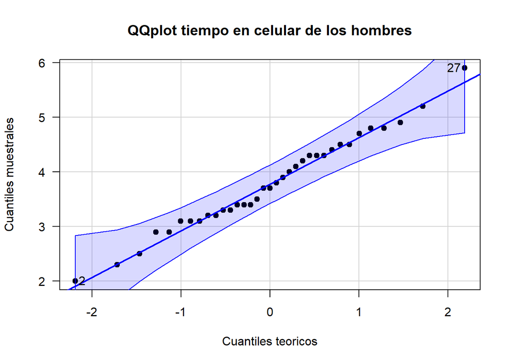

```
## [1] 27  2
```

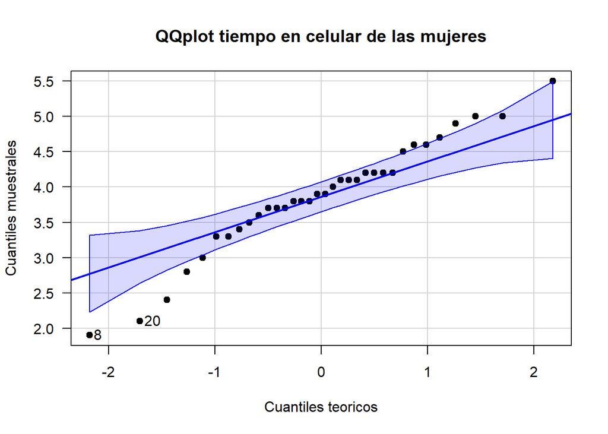

```
## [1]  8 20
```

```
##
##  Shapiro-Wilk normality test
##
## data:  hombres$tiempo_celular
## W = 0.98691, p-value = 0.9439
```

```
##
##  Shapiro-Wilk normality test
##
## data:  mujeres$tiempo_celular
## W = 0.9656, p-value = 0.3512
```

En ambos casos, el valor p de la prueba de Shapiro-Wilk es mayor que 0.05, por lo que no se rechaza la hipótesis nula de normalidad. Esto sugiere que las distribuciones de tiempo en celular tanto para hombres como para mujeres pueden considerarse normales, cumpliendo así el supuesto para aplicar la prueba F.

```
##
##  F test to compare two variances
##
## data:  hombres$tiempo_celular and mujeres$tiempo_celular
## F = 1.1329, num df = 34, denom df = 33, p-value = 0.7215
## alternative hypothesis: true ratio of variances is not equal to 1
## 99 percent confidence interval:
##  0.4539769 2.8121153
## sample estimates:
## ratio of variances
##           1.132898
```

- **Hipótesis nula ($H_0$)**: Las varianzas del tiempo dedicado al celular entre hombres y mujeres son iguales $\;(\sigma_H^2 = \sigma_M^2)$.
- **Hipótesis alternativa ($H_1$)**: Las varianzas del tiempo dedicado al celular entre hombres y mujeres son diferentes $\;(\sigma_H^2 \neq \sigma_M^2)$.

Dado que el p-valor es mayor que $\alpha = 0.01$ ($p = 0.7215 > 0.01$), **no se rechaza la hipótesis nula**. Además, el intervalo de confianza incluye el valor $1$, lo que respalda la conclusión de que **no existe evidencia estadísticamente significativa para afirmar que la variabilidad del tiempo en celular difiera entre hombres y mujeres** en esta muestra.

El cociente estimado de varianzas fue:
$$\frac{\hat{\sigma}_H^2}{\hat{\sigma}_M^2} = 1.133$$
lo que indica que, aunque la varianza en hombres es ligeramente mayor que en mujeres, esta diferencia es pequeña y no significativa estadísticamente.

#### 3.0.6 Enunciado 6.

Para resolver este ejercicio, cambie el tamaño de la muestra a 81 y defina una variable binaria que sea 1 si una persona dedica más de 3 horas al día a internet, y 0 en caso contrario. ¿La proporción de personas que dedican más de 3 horas al día a internet es la misma en hombres y mujeres? Use un alfa de 0.01.

*Solución*

```
## la propocion de hombres es:  0.4615385
```

```
## la propocion de mujeres es:  0.4761905
```

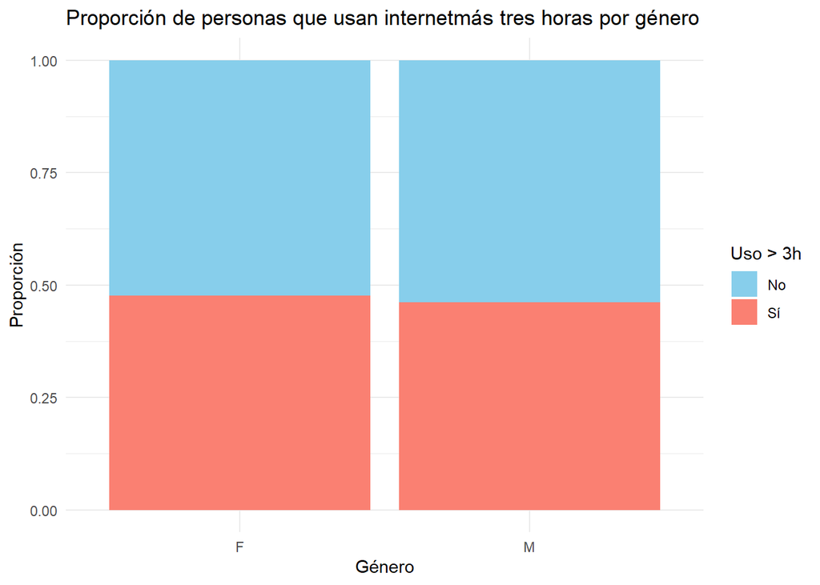

```
##
##  2-sample test for equality of proportions with continuity correction
##
## data:  exitos out of totales
## X-squared = 6.7322e-31, df = 1, p-value = 1
## alternative hypothesis: two.sided
## 99 percent confidence interval:
##  -0.2858034  0.3151075
## sample estimates:
##    prop 1    prop 2
## 0.4761905 0.4615385
```

```
## P-value: 1
```

```
## Nivel de significancia (α): 0.01
```

Con un p-value de 1, que es considerablemente mayor al nivel de significancia establecido (α = 0.01), No se rechaza la hipótesis nula. Por lo tanto, no existe evidencia estadística suficiente para afirmar que hay diferencias significativas en la proporción de personas que dedican más de 3 horas al día a internet entre hombres y mujeres. Las proporciones observadas de 47.6% en mujeres vs 46.2% en hombres, son estadísticamente similares, sugiriendo que el género no es un factor determinante en el comportamiento de uso intensivo de internet en la población estudiada.

#### 3.0.7 Enunciado 7.

Construya un intervalo de confianza del 95% para la diferencia de proporciones entre hombres y mujeres que dedican más de tres horas al día en internet. ¿es consistente el intervalo construido con la conclusión del ejercicio anterior?

*Solución*

```
##
##  2-sample test for equality of proportions with continuity correction
##
## data:  exitos out of totales
## X-squared = 6.7322e-31, df = 1, p-value = 1
## alternative hypothesis: two.sided
## 95 percent confidence interval:
##  -0.2174695  0.2467736
## sample estimates:
##    prop 1    prop 2
## 0.4761905 0.4615385
```

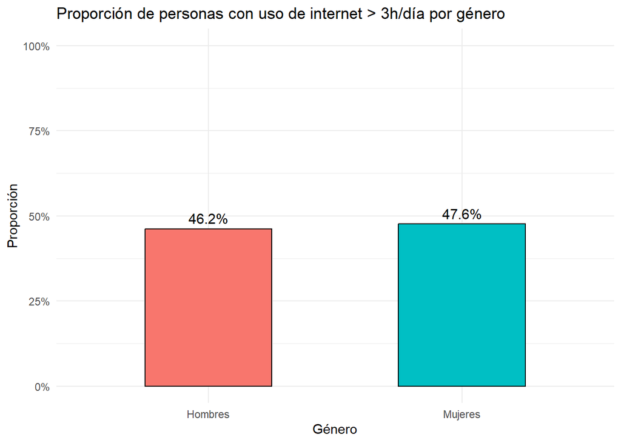

```
## Diferencia de proporciones (p_mujeres - p_hombres): 0.01465201
```

```
## Intevalo de confianza de 95%: -0.2174695 a 0.2467736
```

- **Hipótesis nula ($H_0$)**: $\; p_F - p_M = 0 \;$  
  (la proporción de personas que usan internet más de 3 h/día es igual en mujeres y hombres).
- **Hipótesis alternativa ($H_1$)**: $\; p_F - p_M \neq 0 \;$  
  (la proporción de personas que usan internet más de 3 h/día difiere entre mujeres y hombres).

Dado que $p = 1 > \alpha = 0.01$ y que el intervalo de confianza del 95 % para la diferencia de proporciones incluye el valor $0$, **no se rechaza la hipótesis nula**. Esto significa que, con base en los datos recolectados, no existe evidencia estadísticamente significativa para afirmar que la proporción de personas que dedican más de 3 h/día a internet difiera entre hombres y mujeres en la población estudiada.

En términos prácticos, las proporciones observadas en la muestra ($\hat{p}_F \approx 0.476$ para mujeres y $\hat{p}_M \approx 0.462$ para hombres) son muy cercanas entre sí. La diferencia estimada de apenas $\hat{p}_F - \hat{p}_M \approx 0.0147$ es pequeña y el intervalo de confianza amplio $[ -0.217, \; 0.247 ]$ sugiere que cualquier diferencia real en la población podría ser incluso en sentido contrario o prácticamente nula.

Esto implica que el género, al menos según esta muestra y bajo el nivel de significancia adoptado, **no parece ser un factor determinante en el uso intensivo de internet**. Las variaciones observadas pueden atribuirse al error muestral y no necesariamente a una diferencia real entre hombres y mujeres.

#### 3.0.8 Enunciado 8.

Compare el tiempo promedio dedicado a la lectura entre los estratos 1 y 6. ¿Hay evidencia estadística de una diferencia? Realice una prueba de hipo ́tesis adecuada.

*Solución*

```
##
##  1  6
## 92  7
```

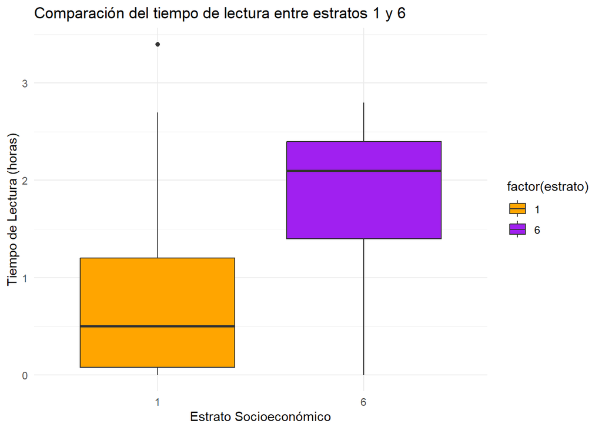

```
##
##  F test to compare two variances
##
## data:  tiempo_lectura by estrato
## F = 0.56037, num df = 91, denom df = 6, p-value = 0.222
## alternative hypothesis: true ratio of variances is not equal to 1
## 95 percent confidence interval:
##  0.1138533 1.4292613
## sample estimates:
## ratio of variances
##          0.5603736
```

```
##
##  Two Sample t-test
##
## data:  tiempo_lectura by estrato
## t = -3.5959, df = 97, p-value = 0.0005105
## alternative hypothesis: true difference in means between group 1 and group 6 is not equal to 0
## 95 percent confidence interval:
##  -1.6157940 -0.4665042
## sample estimates:
## mean in group 1 mean in group 6
##       0.7445652       1.7857143
```

Con un p-value de 0.0005105, que es menor al nivel de significancia convencional (α = 0.05), se rechaza la hipótesis nula. Existe evidencia estadística altamente significativa de que hay diferencias en el tiempo promedio dedicado a la lectura entre los estratos socioeconómicos 1 y 6. Específicamente, las personas del estrato 6 dedican significativamente más tiempo a la lectura (aproximadamente 1.79 horas diarias) comparado con las personas del estrato 1 (aproximadamente 0.74 horas diarias). La diferencia promedio es de aproximadamente 1.04 horas más de lectura diaria en el estrato 6.

#### 3.0.9 Enunciado 9.

¿Existe evidencia estadística para afirmar que el tiempo promedio dedicado al tiempo en celular es diferente entre personas menores de 30 años y personas de 30 años o más? Realice una prueba de hipótesis adecuada con un nivel de significancia α=0.05.

*Solución*

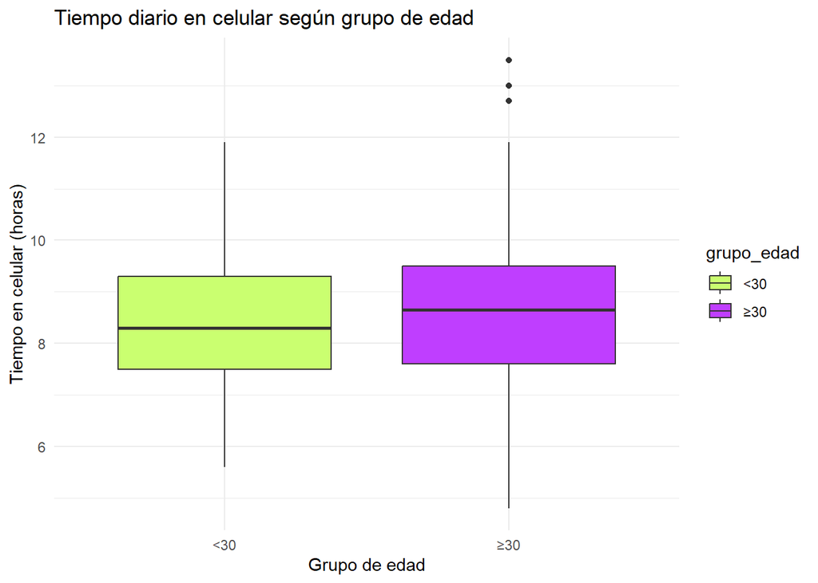

```
##
##  Shapiro-Wilk normality test
##
## data:  filter(baseE, grupo_edad == "<30")$tiempo_total_pantalla
## W = 0.9771, p-value = 0.1169
```

```
##
##  Shapiro-Wilk normality test
##
## data:  filter(baseE, grupo_edad == "≥30")$tiempo_total_pantalla
## W = 0.99011, p-value = 0.1254
```

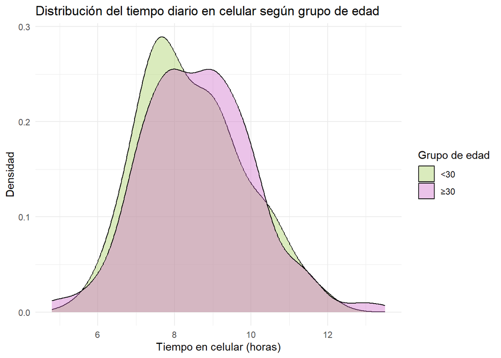

```
##
##  Two Sample t-test
##
## data:  tiempo_total_pantalla by grupo_edad
## t = -0.87794, df = 313, p-value = 0.3806
## alternative hypothesis: true difference in means between group <30 and group ≥30 is not equal to 0
## 95 percent confidence interval:
##  -0.5022007  0.1923071
## sample estimates:
## mean in group <30 mean in group ≥30
##          8.466292          8.621239
```

En otras palabras, los patrones de consumo de pantalla son homogéneos entre ambos grupos etarios, lo que podría relacionarse con la masificación de y redes sociales en todos los rangos de edad adulta.